# Data Exploratin and Deterministic Functions Assignment

Ruichen Wang

```
## here() starts at D:/UMass/Academic/Fall 2022/ECo 602/environmental_data
```

### Terrain Histograms

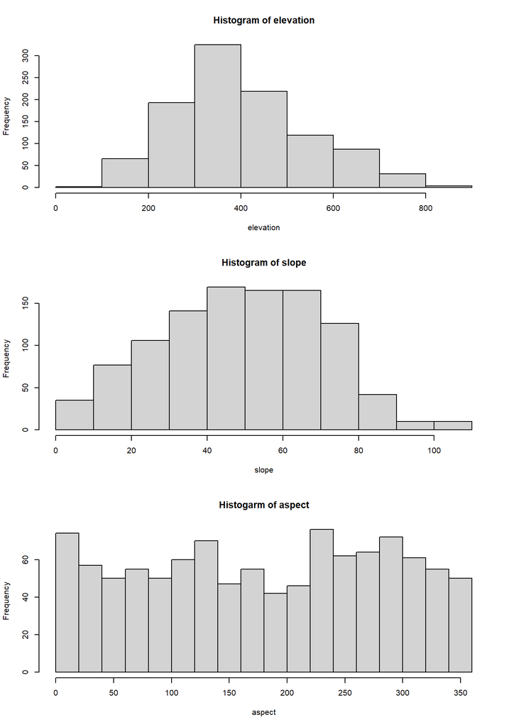

### Scatterplots

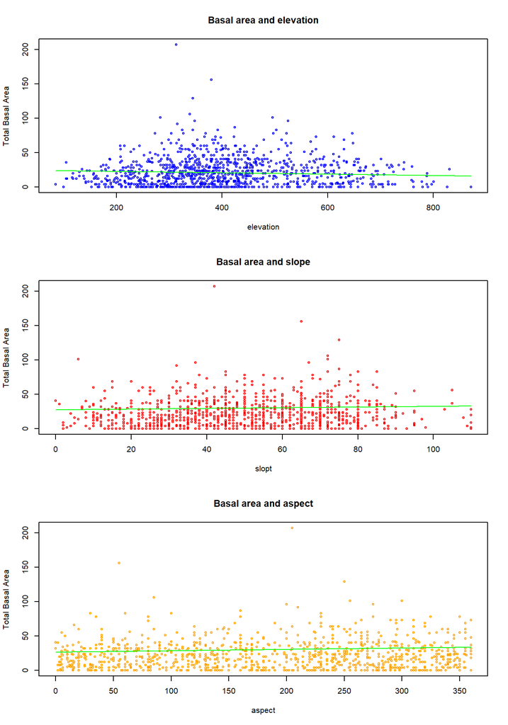

### Assignment Questions

1. Figures see above
2. The distribution of elevation at the bird census sample sites is a shape of normal distribution. There are more sampling sites from 200-500 m, which is approximately in the middle of the range. Neither high- nor low-elevation has a high frequency.
3. The slope is described as percent slope, ranging from 0 - 110, and is unitless.
4. The distribution of the slope at the bird census sample sites is a shape of normal distribution. There are more sampling sites from 40-60% slope, which is approximately in the middle of the range. Neither too flat nor too steep of a slope has a high frequency.
5. Aspect is the direction that a slope faces. The unit of aspect in this data set is degree, ranging from 0 to 360 degrees.
6. The distribution of the aspect at the bird census sample sites is evenly distributed. The frequency of the aspects is about the same, and neither north-facing nor south-facing aspect is dominating.
7. Figures see above
8. There is not a noticeable association. My linear model seems not fit the data very well because there is not a visually clear trend.